# Modern Regression Analysis Assignment 8

Jigar Khatri

## 8.4 Refer to Muscle Mass Problem 1.27. A person’s muscle mass is expected to decrease with age. To explore this relationship in women, a nutritionist randomly selected 15 women from each 10 year age group beginning with age 40 and ending with age 79. X is age and Y is a measure of muscle mass. A second order regression model 8.2 with independent normal error terms is expected to be appropriate.

### 8.4a Fit regression model 8.2. Plot the regression function and data. Does the quadratic regression function appear to be a good fit? Find the $R^2$.

```r
# Muscle Mass is supposed to decrease with age. Y is muscle mass and X is age in years.

Muscle_Mass <- read.csv("Muscle_Mass.csv")
head(Muscle_Mass)
```

|  | Y | X |
| --- | --- | --- |
| 1 | 106 | 43 |
| 2 | 106 | 41 |
| 3 | 97 | 47 |
| 4 | 113 | 46 |
| 5 | 96 | 45 |
| 6 | 119 | 41 |

|  | Y <int> | X <int> |  |  |
| --- | --- | --- | --- | --- |
| 1 | 106 | 43 |  |  |
| 2 | 106 | 41 |  |  |
| 3 | 97 | 47 |  |  |
| 4 | 113 | 46 |  |  |
| 5 | 96 | 45 |  |  |
| 6 | 119 | 41 |  |  |

6 rows

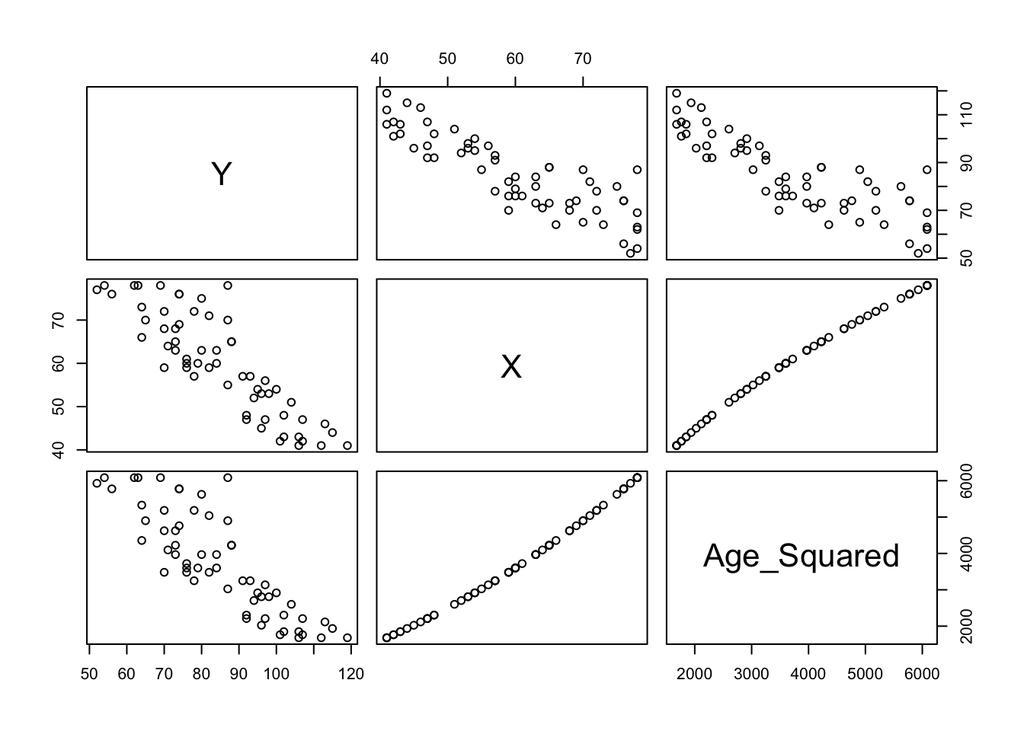

```r
 # Squaring the X value age and saving it to a variable to add it to a new dataframe
Age_Squared = Muscle_Mass$X^2.

# Combining the squared age value to the original df to create a new dataframe
Muscle_Mass2 <- cbind(Muscle_Mass,Age_Squared)

# Visualizing relationships between variable with a pairs plot
pairs(Muscle_Mass2)
```

```r
# Measuring correlation between variables
round(cor(Muscle_Mass2),digits=2)
```

```
##                 Y     X Age_Squared
## Y            1.00 -0.87       -0.85
## X           -0.87  1.00        1.00
## Age_Squared -0.85  1.00        1.00
```

### The pairs plot and the correlation table both indicate strong correlation between the two independent variables. The existence of multicollinearity makes it difficult to interpret coefficients and makes regression estimates less precise. This ultimately makes it difficult to determine which coefficients are statistically significant. Centering indepdendent variables is one technique to correct for multicollinearity.

```r
# Centering the values to eliminate multicollinearity
Age_centered <- Muscle_Mass$X - mean(Muscle_Mass$X)

# Creating a new dataframe with the centered values.
centered_df <- cbind(Muscle_Mass,Age_centered)
head(centered_df)
```

|  | Y | X | Age_centered |
| --- | --- | --- | --- |
| 1 | 106 | 43 | -16.98333 |
| 2 | 106 | 41 | -18.98333 |
| 3 | 97 | 47 | -12.98333 |
| 4 | 113 | 46 | -13.98333 |
| 5 | 96 | 45 | -14.98333 |
| 6 | 119 | 41 | -18.98333 |

|  | Y <int> | X <int> | Age_centered <dbl> |  |
| --- | --- | --- | --- | --- |
| 1 | 106 | 43 | -16.98333 |  |
| 2 | 106 | 41 | -18.98333 |  |
| 3 | 97 | 47 | -12.98333 |  |
| 4 | 113 | 46 | -13.98333 |  |
| 5 | 96 | 45 | -14.98333 |  |
| 6 | 119 | 41 | -18.98333 |  |

6 rows

```r
# Checking correlation between the centered X value and it's squared value.
cor(centered_df$Age_centered,centered_df$Age_centered^2)
```

```
## [1] -0.03835694
```

```r
# Fitting the model and checking the summary statistics. I function is used to account for interaction effects.
mquad <- lm(Y~Age_centered + I(Age_centered^2), data= centered_df); summary(mquad)
```

```
##
## Call:
## lm(formula = Y ~ Age_centered + I(Age_centered^2), data = centered_df)
##
## Residuals:
##     Min      1Q  Median      3Q     Max
## -15.086  -6.154  -1.088   6.220  20.578
##
## Coefficients:
##                    Estimate Std. Error t value Pr(>|t|)
## (Intercept)       82.935749   1.543146  53.745   <2e-16 ***
## Age_centered      -1.183958   0.088633 -13.358   <2e-16 ***
## I(Age_centered^2)  0.014840   0.008357   1.776   0.0811 .
## ---
## Signif. codes:  0 '***' 0.001 '**' 0.01 '*' 0.05 '.' 0.1 ' ' 1
##
## Residual standard error: 8.026 on 57 degrees of freedom
## Multiple R-squared:  0.7632, Adjusted R-squared:  0.7549
## F-statistic: 91.84 on 2 and 57 DF,  p-value: < 2.2e-16
```

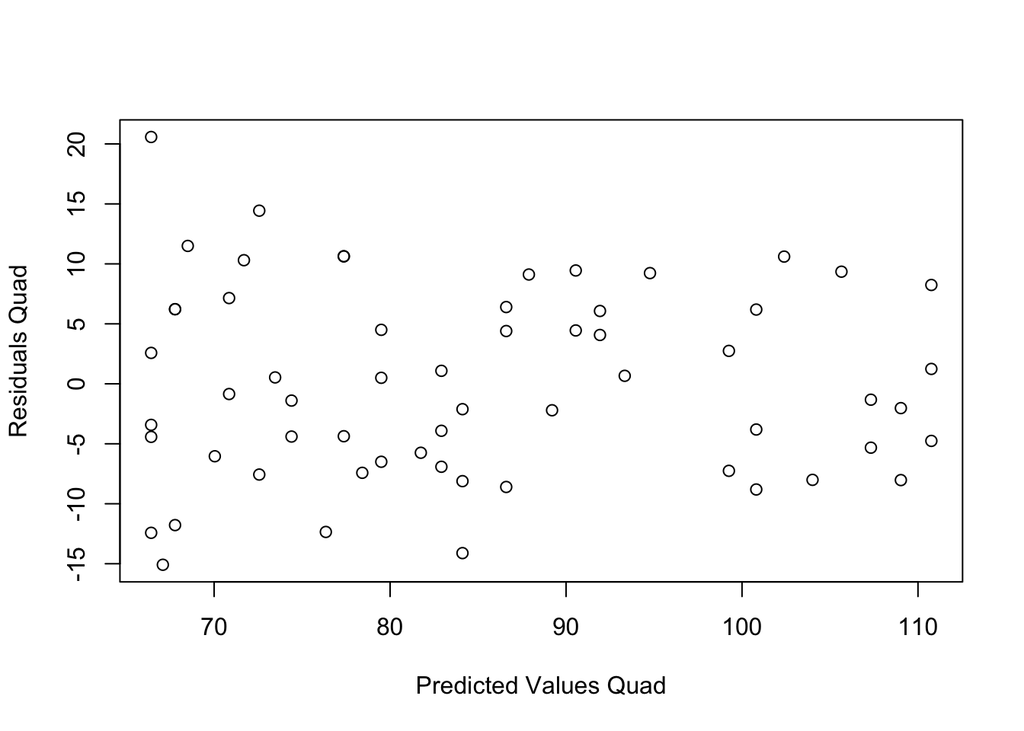

```r
# Plotting the residuals against the fitted values for regression diagnostics.
plot(mquad$residuals~mquad$fitted.values,xlab = "Predicted Values Quad", ylab = "Residuals Quad")
```

### 8.4b Test whether or not there is a regression relation. Use alpha of 0.05. State alternatives, decision rule, and conclusion

##### H<sub>0</sub>: B<sub>1</sub> = B<sub>2</sub> = 0

##### H<sub>a</sub>: At least one of the coefficients, B<sub>1</sub> and B<sub>2</sub> is not equal to 0.

##### Decision rule: If F statistic (aka F*) > F-critical value, reject null and conclude Ha. Otherwise, fail to reject null hypothesis.

```r
### Question is asking us to conduct an F-Test.

print(paste("F-critical value given alpha of 0.05, numerator df 2, and denominator df of 57:" , round(qf(0.05,2,57,lower.tail = FALSE), digits = 4)))
```

```
## [1] "F-critical value given alpha of 0.05, numerator df 2, and denominator df of 57: 3.1588"
```

```r
anova(mquad)
```

|  | Df | Sum Sq | Mean Sq | F value | Pr(>F) |
| --- | --- | --- | --- | --- | --- |
| Age_centered | 1 | 11627.4858 | 11627.48584 | 180.525814 | 2.594561e-19 |
| I(Age_centered^2) | 1 | 203.1349 | 203.13491 | 3.153828 | 8.108690e-02 |
| Residuals | 57 | 3671.3126 | 64.40899 | NA | NA |

|  | Df <int> | Sum Sq <dbl> | Mean Sq <dbl> | F value <dbl> | Pr(>F) <dbl> |
| --- | --- | --- | --- | --- | --- |
| Age_centered | 1 | 11627.4858 | 11627.48584 | 180.525814 | 2.594561e-19 |
| I(Age_centered^2) | 1 | 203.1349 | 203.13491 | 3.153828 | 8.108690e-02 |
| Residuals | 57 | 3671.3126 | 64.40899 | NA | NA |

3 rows

```r
summary(mquad)
```

```
##
## Call:
## lm(formula = Y ~ Age_centered + I(Age_centered^2), data = centered_df)
##
## Residuals:
##     Min      1Q  Median      3Q     Max
## -15.086  -6.154  -1.088   6.220  20.578
##
## Coefficients:
##                    Estimate Std. Error t value Pr(>|t|)
## (Intercept)       82.935749   1.543146  53.745   <2e-16 ***
## Age_centered      -1.183958   0.088633 -13.358   <2e-16 ***
## I(Age_centered^2)  0.014840   0.008357   1.776   0.0811 .
## ---
## Signif. codes:  0 '***' 0.001 '**' 0.01 '*' 0.05 '.' 0.1 ' ' 1
##
## Residual standard error: 8.026 on 57 degrees of freedom
## Multiple R-squared:  0.7632, Adjusted R-squared:  0.7549
## F-statistic: 91.84 on 2 and 57 DF,  p-value: < 2.2e-16
```

##### The F statistic from the summary table is 91.84. We can calculate that value from the ANOVA table as well by summing the mean squared values for each of the independent variables and dividing by their numerator degrees of freedom which is going to be 1 for each independent variable ((11627.5 + 203.1)/2) = 5915.3. This is our mean sqaured regression value (aka MSR). We then divide 5915.3 by the mean squared value of the residuals (64.4) which gives us 91.85 for the F-statistic which is about the same as the value in our summary table. Since the F-Statistic of 91.84 is greater than the F-critical value of 3.158843, we reject the null hypothesis and conclude Ha which is that at least one of the coefficients is not equal to zero.

### 8.4c Estimate the mean muscle mass for women aged 48 years; use a 95 percent confidence interval. Interpret your interval.

```r
# Plug in the centered value of the Age and not 48 to get the correct answer.
predict(mquad,data.frame(Age_centered = -11.98333333 ),level=0.95,interval = "confidence")
```

```
##        fit      lwr      upr
## 1 99.25461 96.28436 102.2249
```

##### The mean muscle mass estimated by the regression function for a 48 year old woman is 99.25461 lbs (aka our point estimate). Using a 95% level of confidence, the lower bound of the confidence interval is 96.28436 and the upper bound of the interval is 102.2249. What this means is that we can be 95% confident that the population mean muscle mass for a 48 year old woman is between 96.28436 and 102.2249. If you take a large number of samples (say 100) and calculate a confidence interval of the mean from each sample, 95 of the intervals would contain the the population mean muscle mass for a 48 year old woman.

### 8.4d Predict the mean muscle mass for women aged 48 years; use a 95 percent confidence interval. Interpret your interval.

```r
# Plug in the centered value of Age and not 48 to get the correct answer.
predict(mquad,data.frame(Age_centered = -11.98333333 ),level=0.95,interval = "prediction")
```

```
##        fit     lwr      upr
## 1 99.25461 82.9116 115.5976
```

##### The mean muscle mass estimated by the regression function for a 48 year woman is 99.25461 lbs (aka our point estimate). The lower bound of the prediction interval is 82.9116 and the upper bound of the interval is 115.5976. Unlike the confidence interval, which involves constructing an interval that contains the population parameter being estimated with a certain degree of confidence, the prediction interval produces a range that contains the value of the response variable for a new observation based on the specific values of the predictor variable(s). For this problem we can say that we are 95% confident that if measured the muscle mass of a new 48 year old woman, the measured muscle mass would fall between 82.9116 and 115.5976 lbs. As can be seen from the output, the prediction interval is wider due to the greater uncertainty involved in predicting the value of a new observation (as opposed to the confidence interval which is focused on estimating the parameter value based on the mean of the existing observations). Given this greater uncertainty, we need a wider interval to get to a 95% level of confidence. So in sum, we accept less precision to maintain the same level of confidence.

### 8.4e Test whether the quadratic term can be dropped from the regression model. Use alpha = 0.05. State alternatives, decision rule, and conclusion.

##### Alternatives are H<sub>0</sub>: B<sub>11</sub> equals 0, H<sub>a</sub>: B<sub>11</sub> does not equal 0. Alpha = 0.05.

##### Decision rule: If |t*| > t-critical value reject null hypothesis and conclude Ha. Otherwise, fail to reject null hypothesis.

```r
summary(mquad)
```

```
##
## Call:
## lm(formula = Y ~ Age_centered + I(Age_centered^2), data = centered_df)
##
## Residuals:
##     Min      1Q  Median      3Q     Max
## -15.086  -6.154  -1.088   6.220  20.578
##
## Coefficients:
##                    Estimate Std. Error t value Pr(>|t|)
## (Intercept)       82.935749   1.543146  53.745   <2e-16 ***
## Age_centered      -1.183958   0.088633 -13.358   <2e-16 ***
## I(Age_centered^2)  0.014840   0.008357   1.776   0.0811 .
## ---
## Signif. codes:  0 '***' 0.001 '**' 0.01 '*' 0.05 '.' 0.1 ' ' 1
##
## Residual standard error: 8.026 on 57 degrees of freedom
## Multiple R-squared:  0.7632, Adjusted R-squared:  0.7549
## F-statistic: 91.84 on 2 and 57 DF,  p-value: < 2.2e-16
```

```r
print(paste("T-critical value for 5% alpha and 57 df:",round((qt(0.975,57)),digits = 4)))
```

```
## [1] "T-critical value for 5% alpha and 57 df: 2.0025"
```

##### Conclusion: The absolute value of t* is 1.776 (which can be computed manually by dividing the point estimate of the quadratic term by it’s standard error: 0.014840/0.008357), and because it is less than the t-critical value of 2.0025, we fail to reject the null hypothesis. This means that the coefficient is not statistically significant using an alpha of 0.05 so we can drop it from the model. Alternatively, you can also see that the p-value of the coefficient is greater than alpha so that is also an indication that it is not statistically significant.

### 8.4f Express the fitted regression function obtained in part a in terms of the original variable X

```r
fitted_model <- lm(Y~X + Age_Squared, data = Muscle_Mass2)
summary(fitted_model)
```

```
##
## Call:
## lm(formula = Y ~ X + Age_Squared, data = Muscle_Mass2)
##
## Residuals:
##     Min      1Q  Median      3Q     Max
## -15.086  -6.154  -1.088   6.220  20.578
##
## Coefficients:
##               Estimate Std. Error t value Pr(>|t|)
## (Intercept) 207.349608  29.225118   7.095 2.21e-09 ***
## X            -2.964323   1.003031  -2.955  0.00453 **
## Age_Squared   0.014840   0.008357   1.776  0.08109 .
## ---
## Signif. codes:  0 '***' 0.001 '**' 0.01 '*' 0.05 '.' 0.1 ' ' 1
##
## Residual standard error: 8.026 on 57 degrees of freedom
## Multiple R-squared:  0.7632, Adjusted R-squared:  0.7549
## F-statistic: 91.84 on 2 and 57 DF,  p-value: < 2.2e-16
```

##### Regression Function: E{Y} = 207.349608 - 2.964323X + 0.014840$X^2$

### Calculate the coefficient of simple correlation between X and $X^2$. Is the use of a centered variable helpful here?

```r
print(paste("Correlation between X and X^2:",cor(Muscle_Mass2$X,Muscle_Mass2$Age_Squared)))
```

```
## [1] "Correlation between X and X^2: 0.996093917056547"
```

```r
print(paste("Correlation between X and centered version of X^2:",cor(centered_df$Age_c,centered_df$Age_c^2)))
```

```
## [1] "Correlation between X and centered version of X^2: -0.0383569363064234"
```

##### The correlation between X and $X^2$ is very high in the non-centered dataframe (99.6%) which indicates a problem with multicollinearity. Multicollinearity reduces the precision of the estimates and makes them harder to interpret by changing the coefficient estimates substantially and inflating the standard errors. Using the centered variable helps a lot in this case since the correlation drops from a very strong positive correlation of 99.6% to a very weak negative correlation of -3.84%.

## 8.5 Refer to Muscle Mass Problems 1.27 and 8.4 A person’s muscle mass is expected to decrease with age. To explore this relationship in women, a nutritionist randomly selected 15 women from each 10 year age group beginning with age 40 and ending with age 79. X is age and Y is a measure of muscle mass. A second order regression model 8.2 with independent normal error terms is expected to be appropriate.

### 8.5a Obtain the residuals from the fit in 8.4a and plot them against $\hat{Y}$ and against X on separate graphs. Also prepare a normal probability plot. Interpret your plots.

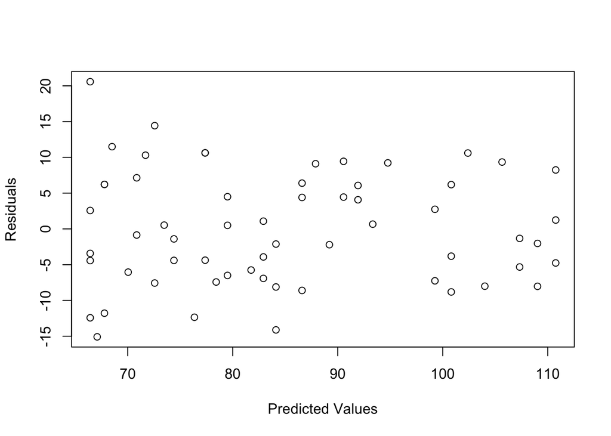

```r
plot(mquad$residuals~mquad$fitted.values,xlab = "Predicted Values", ylab = "Residuals")
```

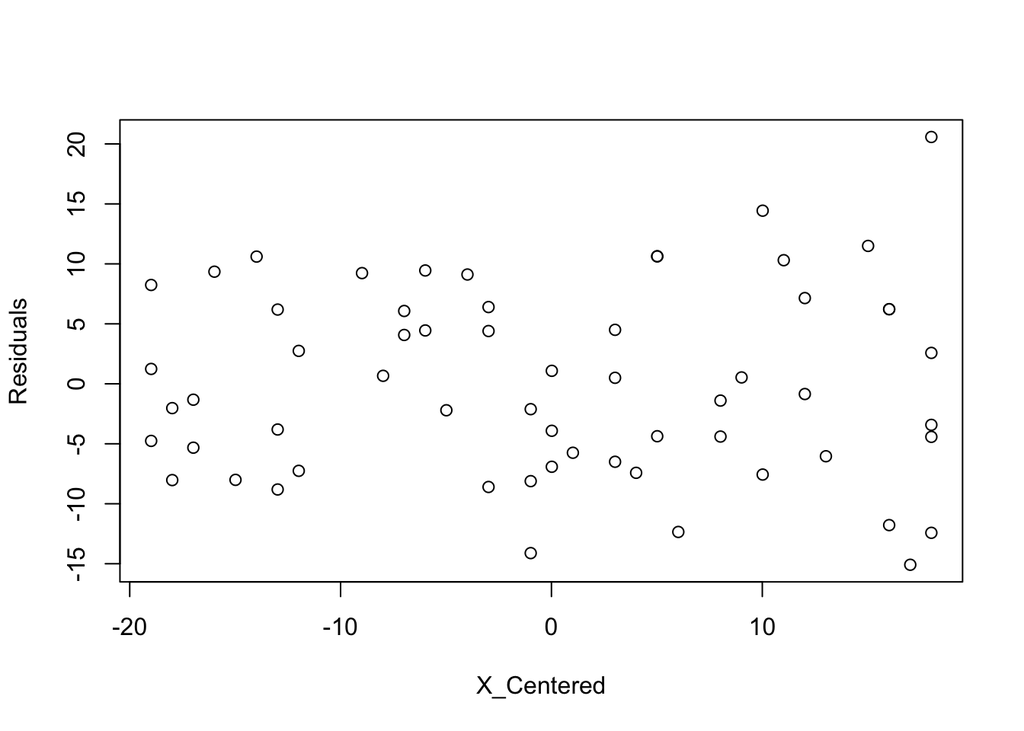

```r
plot(mquad$residuals~centered_df$Age_centered,xlab ="X_Centered", ylab = "Residuals")
```

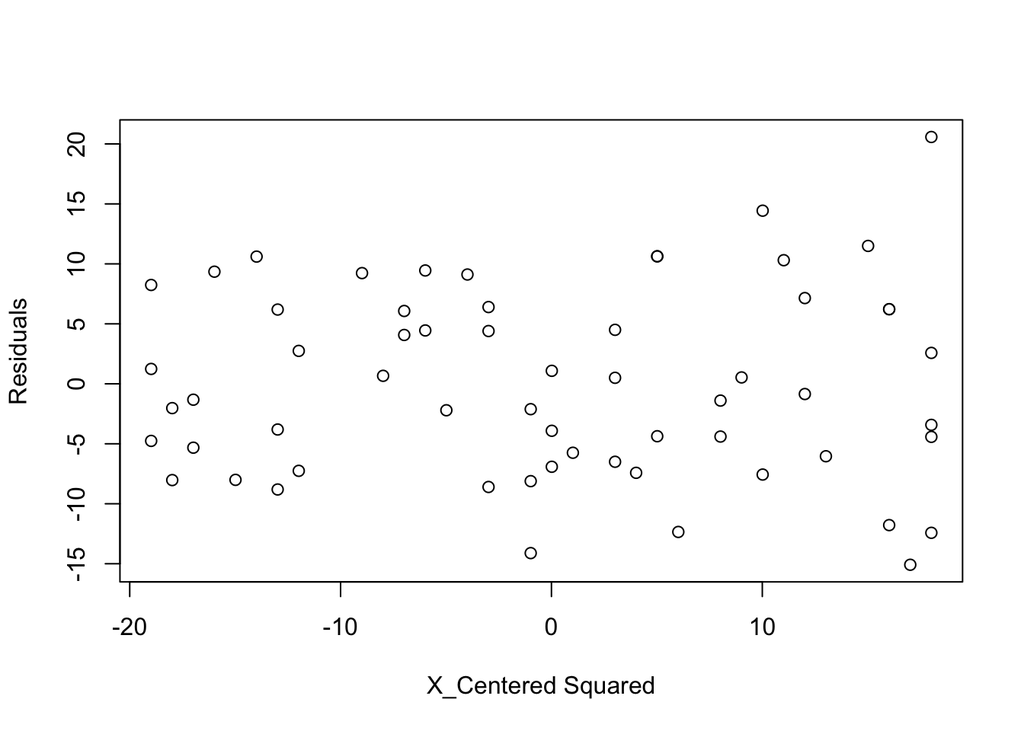

```r
plot(mquad$residuals~centered_df$Age_centered^2,xlab ="X_Centered Squared", ylab = "Residuals")
```

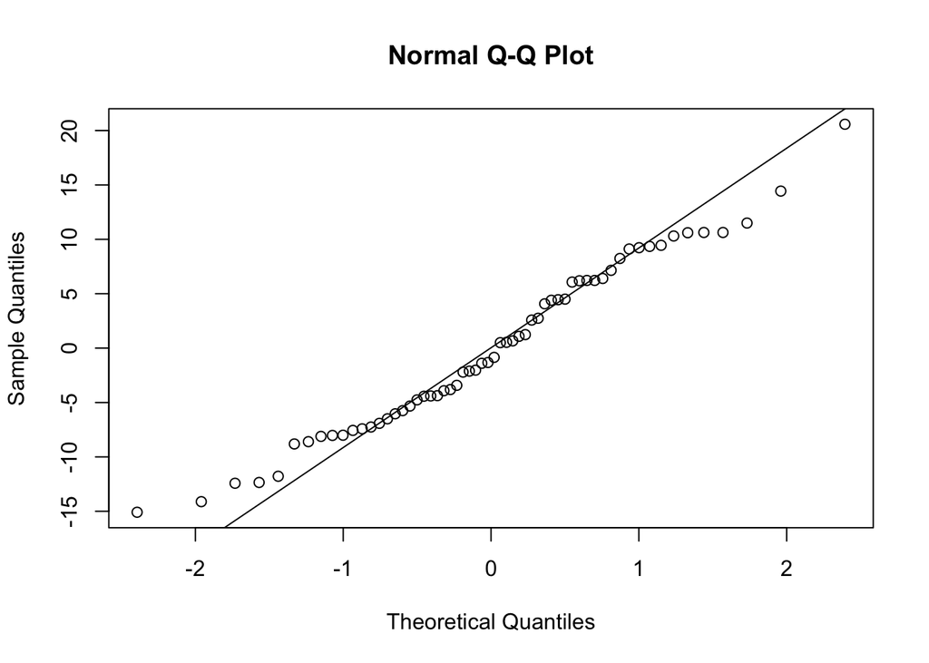

```r
residuals <- resid(mquad)

qqnorm(residuals)
qqline(residuals)
```

### 8.5b Test formally for lack of fit of the quadratic function using alpha of 0.05. State the alternatives, decision rule and conclusion. What assumptions did you make implicitly in this test.

##### H<sub>0</sub>: Reduced model: E{Y} = B<sub>0</sub> + B<sub>11</sub>X1 + B<sub>11</sub>X1^2

##### H<sub>a</sub>: Full model aka categorical model: E{Y} =/= B<sub>0</sub> + B<sub>11</sub>X1 + B<sub>11</sub>X1^2,

##### F* = MSLF/MSPE. MSLF = SSLF/(c-p). MSPE = SSPE/(n-c). c = number of unique values, p = number of predictor variables. SSLF = SSE(Reduced Model) - SSE(Full Model). SSPE = SSE Full Model.

##### Decision Rule: Conclude Ha if F* > F-critical value of F(1-alpha;c-p;n-c), otherwise fail to reject null hypothesis.

```r
#factor function is used to get unique values only(no duplicates).
x1factor <- factor(centered_df$Age_centered)
x1sq_factor <- factor(centered_df$Age_centered^2)


mlin_f <- lm(Y~factor(Age_centered),data = centered_df)
anova(mquad,mlin_f)
```

|  | Res.Df | RSS | Df | Sum of Sq | F | Pr(>F) |
| --- | --- | --- | --- | --- | --- | --- |
| 1 | 57 | 3671.313 | NA | NA | NA | NA |
| 2 | 28 | 1849.667 | 29 | 1821.646 | 0.9508905 | 0.553866 |

|  | Res.Df <dbl> | RSS <dbl> | Df <dbl> | Sum of Sq <dbl> | F <dbl> | Pr(>F) <dbl> |
| --- | --- | --- | --- | --- | --- | --- |
| 1 | 57 | 3671.313 | NA | NA | NA | NA |
| 2 | 28 | 1849.667 | 29 | 1821.646 | 0.9508905 | 0.553866 |

2 rows

```r
c <- factor(centered_df$Age_centered) # 32 unique values. c- p = 32 - 3 = 29

f_crit <- qf(0.95,29,28,lower.tail = TRUE)

print(paste("F critical value:",round(f_crit,digits = 4)))
```

```
## [1] "F critical value: 1.8752"
```

##### Since the F* value of 0.95 is less than the F-critical value of 1.8752 we fail to reject the null hypothesis (there is no issue with lack of fit with the Reduced Model). In this test we assume that the Reduced Model is appropriate unless there is significant statistical evidence to conclude otherwise. In this case since there is not enough evidence to reject the baseline assumption that the relationship is approriate we conclude that there is no issue with lack of fit.

### 8.5c Fit third order model (8.6) and test whether or not B<sub>111</sub> = 0. Use alpha = 0.05. State alternatives, decision rule, and conclusion. Is your conclusion consistent with your finding in part b.

#### - H<sub>0</sub> aka Null: B<sub>111</sub> = 0, H<sub>a</sub>: B<sub>111</sub> is not equal to 0, Alpha = 0.05.

#### - Decision rule: If |t*| > t-critical value(.975, 56 df) we reject H<sub>0</sub> and conclude H<sub>a</sub>. Otherwise fail to reject the null hypothesis.

```r
centered_df2 <- subset(centered_df, select = -c(X)) #drop the original X column and save as new df
Age_c2 <- centered_df2$Age_centered^2 # create vector where the centered column is squared
Age_c3 <- centered_df2$Age_centered^3 #create vector where centered column is cubed
third_order_df <- cbind(centered_df2,Age_c2,Age_c3) #add them to the dataframe you created and save as new df
third_order_model <- lm(Y~Age_centered + Age_c2 + Age_c3, data = third_order_df) #specify the third order model

summary(third_order_model)
```

```
##
## Call:
## lm(formula = Y ~ Age_centered + Age_c2 + Age_c3, data = third_order_df)
##
## Residuals:
##      Min       1Q   Median       3Q      Max
## -15.3671  -5.8483  -0.6755   6.1376  20.0637
##
## Coefficients:
##                Estimate Std. Error t value Pr(>|t|)
## (Intercept)  82.9273444  1.5552264  53.322  < 2e-16 ***
## Age_centered -1.2678894  0.2489231  -5.093 4.28e-06 ***
## Age_c2        0.0150390  0.0084390   1.782   0.0802 .
## Age_c3        0.0003369  0.0009327   0.361   0.7193
## ---
## Signif. codes:  0 '***' 0.001 '**' 0.01 '*' 0.05 '.' 0.1 ' ' 1
##
## Residual standard error: 8.087 on 56 degrees of freedom
## Multiple R-squared:  0.7637, Adjusted R-squared:  0.7511
## F-statistic: 60.34 on 3 and 56 DF,  p-value: < 2.2e-16
```

```r
t_crit <- qt(0.975,56,lower.tail = TRUE)
print(paste("T critical value 1 - 0.05/2; 56 df:", round(t_crit, digits = 4)))
```

```
## [1] "T critical value 1 - 0.05/2; 56 df: 2.0032"
```